# Organisatorische Resilienz II: Rollen und Verantwortlichkeiten

Cyber Security Management · Termin 6

Prof. Dr. Dirk Loomans

Hochschule Mainz · dirk.loomans@hs-mainz.de

## Agenda

- Rückblick & Lernziele
- Einstieg: Target 2013 – der Alarm kam an
- Vom Individuum zur Organisation
- CISO: Mandat und Haftung (Uber, SolarWinds)
- SOC und CERT · externe Rollen (Uniklinik Düsseldorf)
- Weitere Schlüsselrollen · Rollenaufbau (Hochschule Kaiserslautern)
- Eskalation, Meldepflichten, Management (MGM und Caesars)
- Konflikte, Governance-Matrix, Standards
- Übung · Kernpunkte & Ausblick

## Rückblick Sitzung 5

- Organisationale Resilienz: **Technik schafft Potenzial, Organisation aktiviert es**
- **Rollen statt Personen**, Entscheidungskompetenz auf Zeit (Anhalt-Bitterfeld)
- Incident-Management nach ISO/IEC 27035-1 – **jede Phase braucht einen Owner**
- Übung und Lernen ohne Schuldzuweisung (LÜKEX 23, Cloudflare)

**Heute: Welche Rollen sind das konkret – und wo reiben sie sich?**

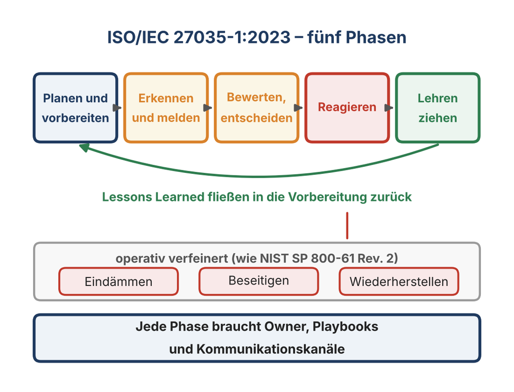

## Lernziele

Nach dieser Sitzung können Sie …

- die zentralen Rollen der Cyber-Resilienz unterscheiden: **CISO, SOC, CERT, DPO, BCM, IT Operations, Management**,
- erklären, warum ein CISO ein **Mandat** braucht – und was ohne Mandat oder bei Vertuschung passiert,
- Eskalationswege, **Meldepflichten** und externe Partner (BSI, CERTs, Polizei) einordnen,
- typische **Rollenkonflikte** erkennen und mit einer Governance-Matrix auflösen,
- die Rollen in einer **Übung** auf einen Vorfall anwenden.

## Einstieg: Target 2013

- Ab **27. November 2013:** Kassen-Malware in den US-Filialen, Zugang über Zugangsdaten eines Dienstleisters
- **30. November:** Das Überwachungsteam in Bangalore meldet einen Alarm an das SOC in Minneapolis – weitere am **2. Dezember**
- Keine Reaktion; am **12. Dezember** informiert das **US-Justizministerium** Target
- **40 Mio. Kartendaten**, bis zu **70 Mio.** weitere Kundendatensätze

**Frage:** Die Erkennung hat funktioniert. Woran ist Target gescheitert?

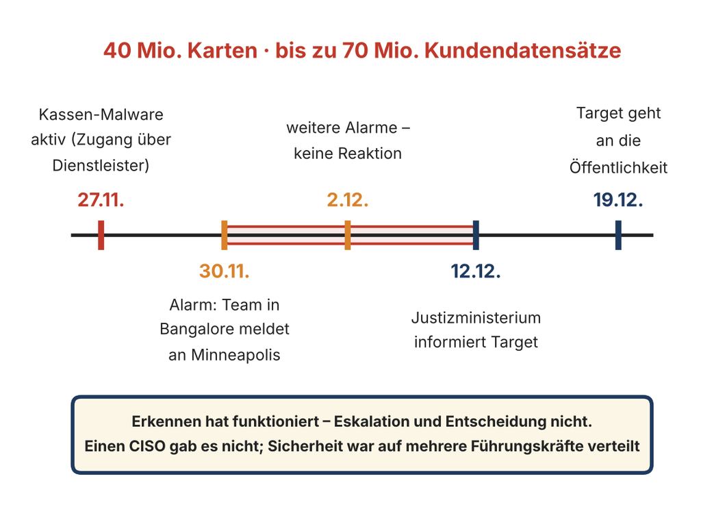

## Vom Individuum zur Organisation

**Warum Rollen das Rückgrat der Resilienz sind**

- Technik kann reagieren – **Menschen entscheiden**.
- Eine Rolle beschreibt **Verantwortung, Befugnis und Schnittstellen**.
- Klare Rollen verhindern Chaos und Doppelarbeit – **Verantwortung ersetzt Schuld**.
- Ohne Struktur keine Geschwindigkeit.

**Beispiele:** Wer schaltet Systeme ab, wenn Malware erkannt wird? Wer informiert Behörden oder Kunden? Wer genehmigt öffentliche Kommunikation?

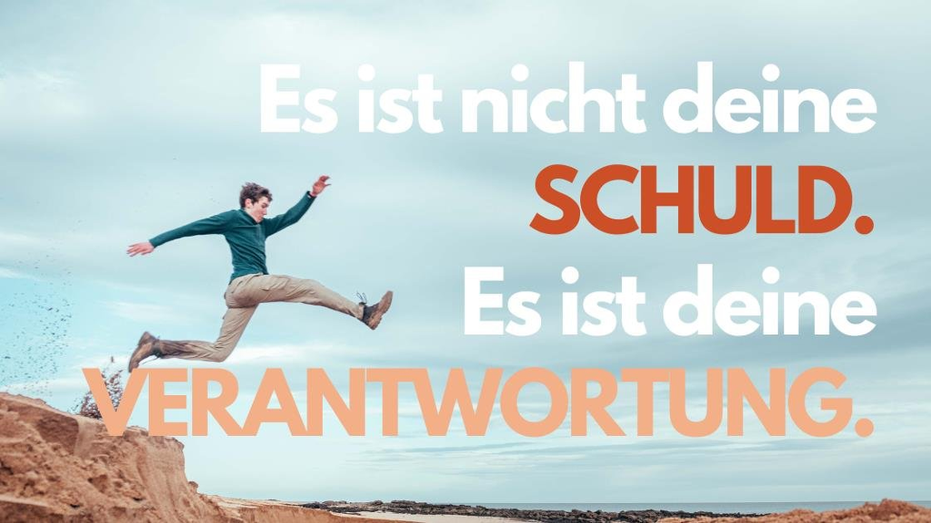

## Die Rolle des CISO

- Strategische Verantwortung für **Informationssicherheit und Cyber-Resilienz**
- Steuert das **ISMS** (ISO/IEC 27001), koordiniert SOC und CERT
- Übersetzt Risiken in **Entscheidungsvorlagen** für die Geschäftsleitung
- Berichtet idealerweise **direkt an die Geschäftsleitung** – getrennt vom IT-Betrieb

**Mandatsdilemma:** Verantwortung ohne Befugnis und Ressourcen – *Accountability without Authority*

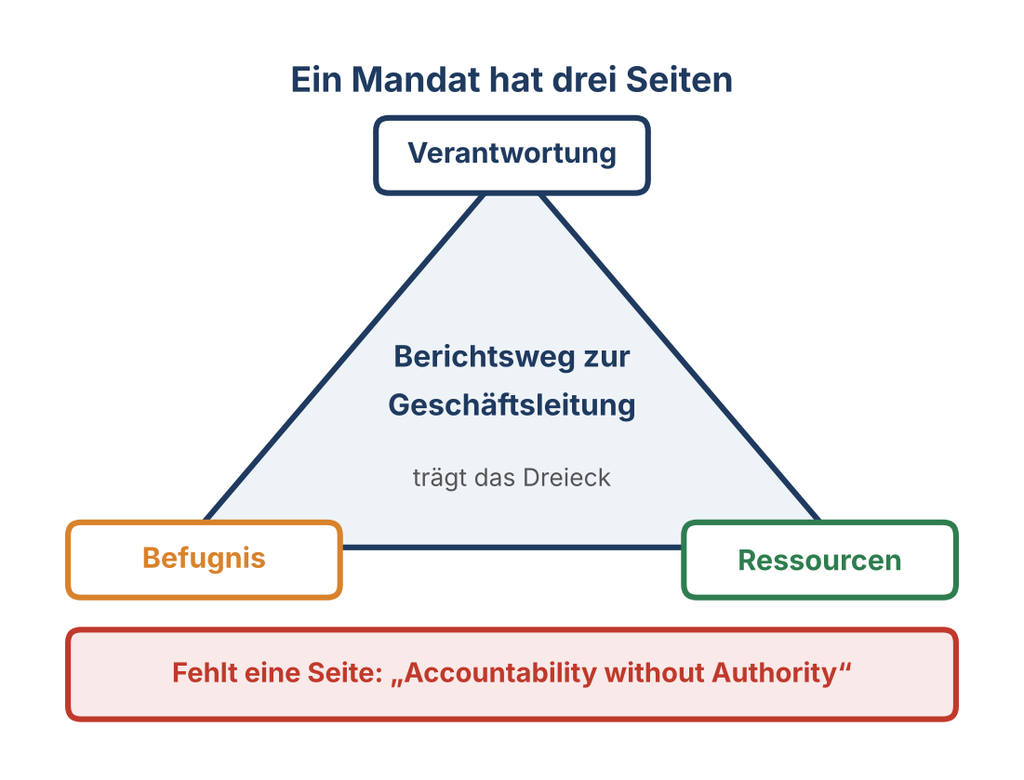

## Fallbeispiel: Uber 2016

- **November 2016:** Angreifer melden dem Sicherheitschef (CSO) einen Datendiebstahl – **57 Mio.** Nutzerdatensätze, **600.000** Führerscheinnummern
- Zahlung von **100.000 USD**, verbucht als **„Bug Bounty“**, gegen Schweigeerklärungen
- Gleichzeitig lief eine **FTC-Untersuchung** zu einem früheren Vorfall – keine Meldung
- **November 2017:** Die neue Unternehmensleitung deckt den Vorfall auf

**Oktober 2022:** Der CSO wird verurteilt – seit Juni 2026 rechtskräftig.

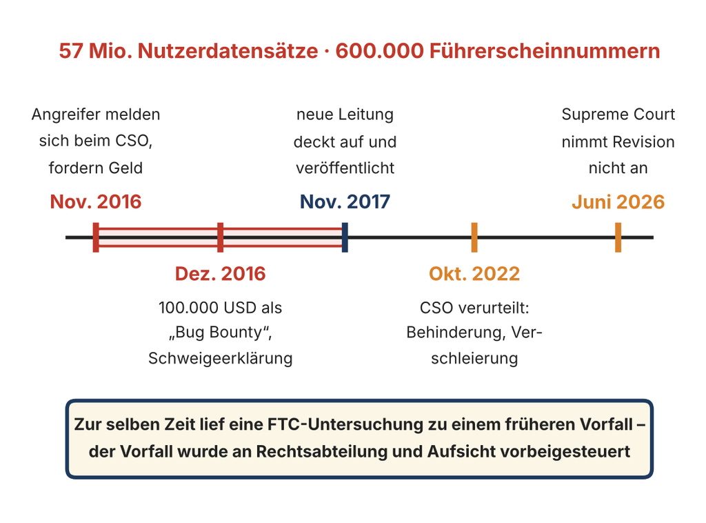

## Fallbeispiel: SolarWinds und die SEC

- **Oktober 2023:** Die US-Börsenaufsicht verklagt SolarWinds **und den CISO persönlich** – erstmals einen Sicherheitsverantwortlichen
- Vorwurf: öffentliche Sicherheitsaussagen passten nicht zu **internen Kenntnissen**
- **Juli 2024:** Gericht weist die meisten Vorwürfe ab
- **November 2025:** Verfahren eingestellt – ohne Schuldeingeständnis

**Gegenstück zu Uber: kein Vertuschen – aber die Frage, wer was intern wusste und weitergab.**

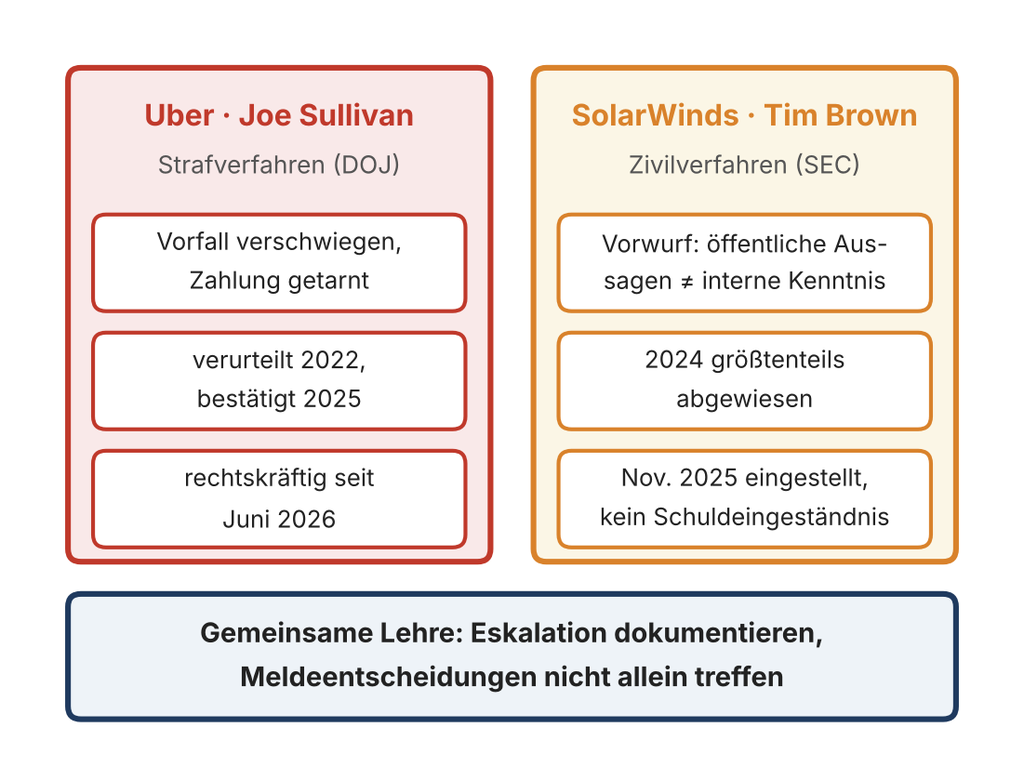

## Das Security Operations Center (SOC)

**Zentrale Aufgaben**

- 24/7-Überwachung von Systemen und Netzwerken
- Erkennung und Analyse von Sicherheitsereignissen (Monitoring & SIEM)
- Eskalation an Incident-Response-Team / CERT
- Dokumentation, Reporting, Threat-Intelligence-Einbindung

**Organisation:** Schnittstellen zu IT Operations, CISO-Office, Datenschutz, Management

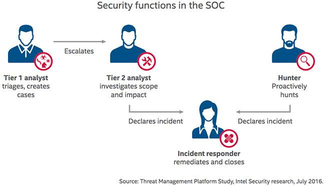

## SOC – Tier 1–3

Resilienz entsteht durch Funktionstrennung und Spezialisierung – nicht durch Mehrarbeit.

| Ebene | Bezeichnung | Aufgabe |
| --- | --- | --- |
| Tier 1 | Monitoring / Analysis | erste Alarmbewertung, Triage, Eskalation |
| Tier 2 | Investigation | vertiefte Analyse, Kontext, Angriffsketten |
| Tier 3 | Response / Threat Hunting | Eindämmung, Forensik, proaktive Suche |

## Das Computer Emergency Response Team (CERT)

**Mandat:** Koordination der technischen Reaktion – Eindämmung, Forensik, Wiederanlauf, Lessons Learned

**SOC erkennt, CERT reagiert.**

- **Internal CERT:** eigene Organisation oder Konzern
- **National:** CERT-Bund beim BSI, mobile Einsatzteams
- **Land und Kommune:** z. B. kommunales CERT Rheinland-Pfalz
- **Sektoral und akademisch:** Branchen-CERTs, DFN-CERT

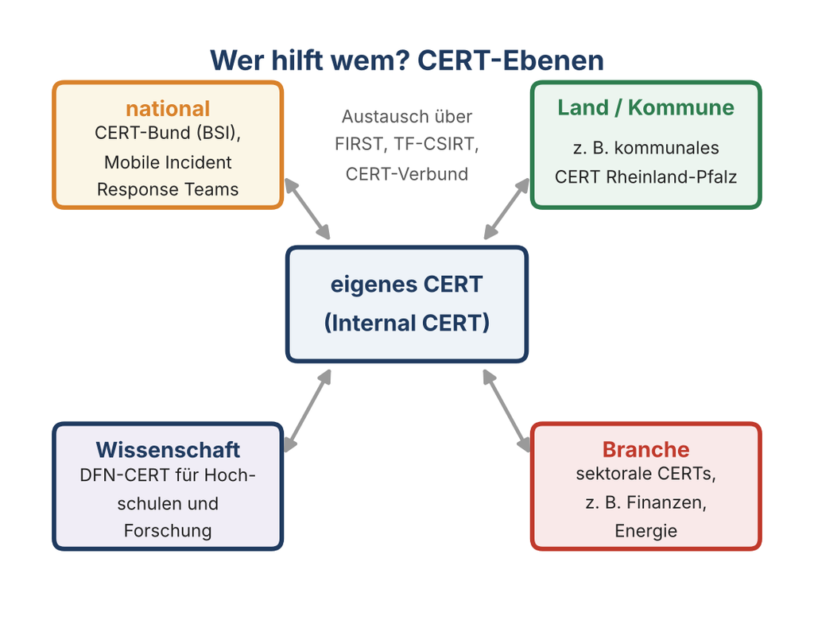

## Fallbeispiel: Uniklinik Düsseldorf 2020

- **10. September 2020:** Ransomware verschlüsselt **30 Server**; Einfallstor eine seit Januar bekannte **Citrix-Lücke**
- Das Klinikum meldet sich **13 Tage** von der Notfallversorgung ab
- **Meldung an das BSI** nach BSI-Gesetz, BSI unterstützt mit einem **mobilen Einsatzteam**
- Erpresserschreiben an die **Universität** gerichtet – nach Hinweis der **Polizei** geben die Täter den Schlüssel heraus

**Viele Rollen kommen von außen – sie müssen vorher bekannt sein.**

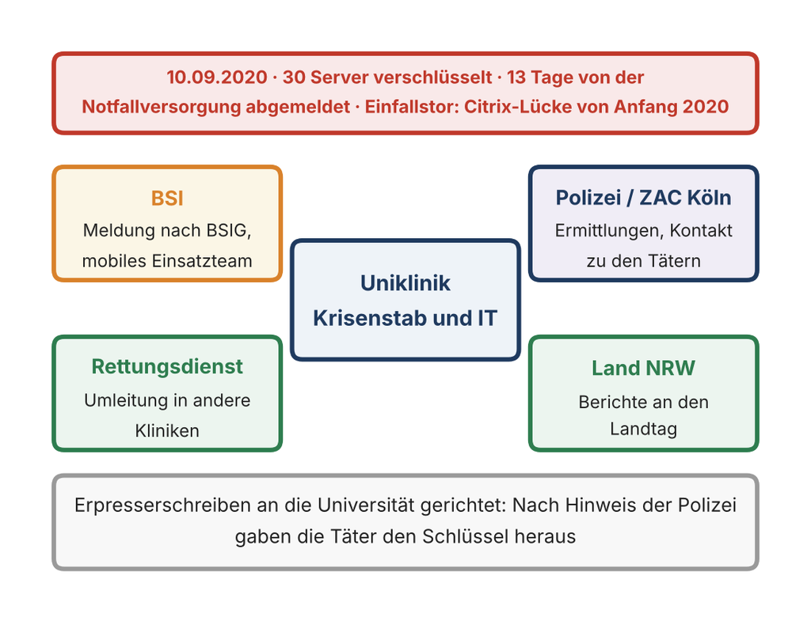

## Zusammenspiel von CISO – SOC – CERT

**Funktionale Trennung = Resilienz durch Arbeitsteilung**

- CISO → Richtlinien, Ressourcen, Reporting (strategisch)
- SOC → Erkennen, Bewerten, Eskalieren (operativ)
- CERT → Koordinieren, Reagieren, Lernen (taktisch)

**Zentrale Erfolgsfaktoren:** definierte Eskalationsschwellen · gemeinsames Lagebild (Single Source of Truth) · regelmäßige Lage- und Lessons-Learned-Meetings

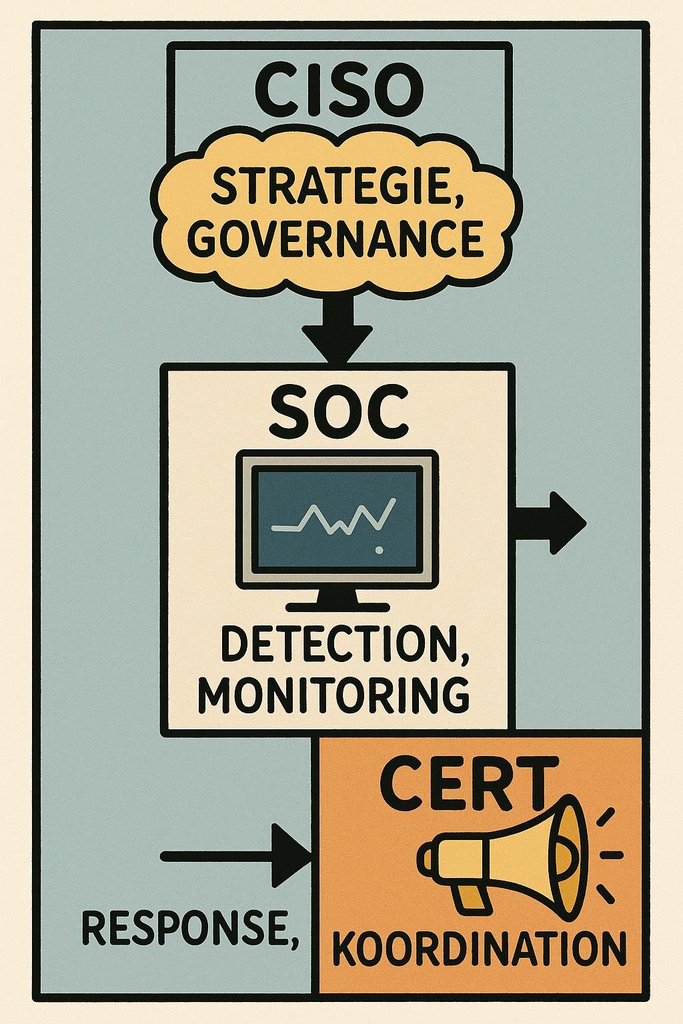

## Weitere Schlüsselrollen in der Cyber-Organisation

Resilienz ist kein Produkt einzelner Spezialisten, sondern kollektive Verantwortlichkeit.

| Rolle | Kernaufgaben | Bezug zur Resilienz |
| --- | --- | --- |
| DPO | Datenschutz, Prüfung der DSGVO-Meldung, Schnittstelle zur Aufsicht | schützt Vertrauen & Reputation |
| BCM Manager | Aufrechterhaltung kritischer Geschäftsprozesse | Recovery & Priorisierung |
| IT Operations Lead | Betrieb, Infrastruktur, Wiederherstellung | technische Umsetzung |
| Risk Manager | Risikoanalyse, Bewertung, Register | Früherkennung & Priorisierung |
| Management Board | Governance, Ressourcen, Risikoakzeptanz | strategische Steuerung |

## Fallbeispiel: Hochschule Kaiserslautern 2023

- **8. Juni 2023:** Angriff auf die gesamte IT – die Hochschule **schaltet früh ab**, bildet einen **Krisenstab** und informiert das LKA
- Austausch mit **BSI, DFN-CERT**, VCRP, ZIT und den Rechenzentren in Mainz und Kaiserslautern
- Juli: erbeutete Daten im Darknet veröffentlicht
- **Januar 2025:** Landesstrategie aller **12 Hochschulen** mit dem Wissenschaftsministerium – **Informationssicherheitsbeauftragte** an jeder Hochschule, direkt beim Präsidium

**Aus dem Vorfall wird eine Rolle.**

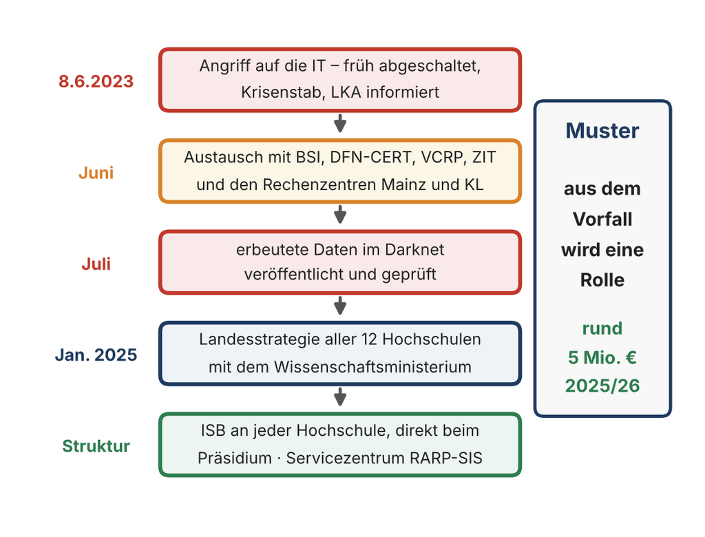

## Kommunikations- und Eskalationsmodell

- **Single Source of Truth:** ein gemeinsames Lagebild
- **Time to Inform:** Informationspflicht in definierten Fristen
- **Bidirektionalität:** Rückmeldungen fließen ins Lagebild
- **Vorab definierte Kanäle** (z. B. Teams-Crisis-Channel) und **Offline-Fallback**
- **Eskalationsschwellen** schriftlich: ab wann CISO, ab wann Geschäftsleitung

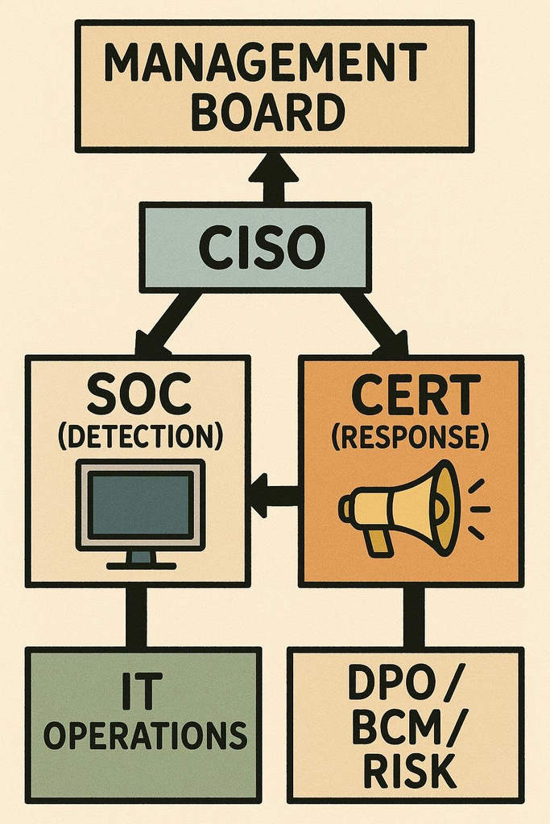

## Meldepflichten

- **§ 32 BSIG** (seit 6.12.2025): erhebliche Sicherheitsvorfälle – Frühwarnung **24 h**, Meldung **72 h**, Abschlussbericht nach **einem Monat**
- **Art. 33 DSGVO:** Datenschutzverletzung binnen **72 h** an die Aufsichtsbehörde
- **Technischer Vorfall ohne Meldepflicht:** trotzdem dokumentieren
- **Betriebsunterbrechung:** BCM-relevant, Eskalation nach BIA

**Nicht jeder Incident ist meldepflichtig – aber jeder muss dokumentiert werden.**

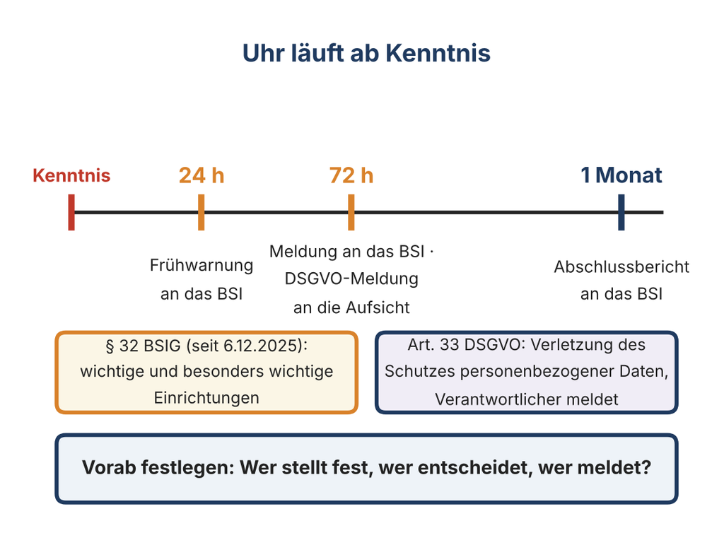

## Fallbeispiel: MGM und Caesars 2023

- **September 2023:** dieselbe Angreifergruppe trifft zwei Casino-Konzerne in Las Vegas – Einstieg über **Social Engineering beim IT-Support**
- **Caesars:** Kundendatenbank kopiert, Betrieb ungestört; laut Medien rund **15 Mio. USD** gezahlt, damit die Daten gelöscht werden
- **MGM:** zahlt nicht, schaltet Systeme ab – rund **10 Tage** Störung, rund **100 Mio. USD** weniger Ergebnis

**Zahlen oder nicht ist keine Technikfrage, sondern eine Entscheidung der Leitung.**

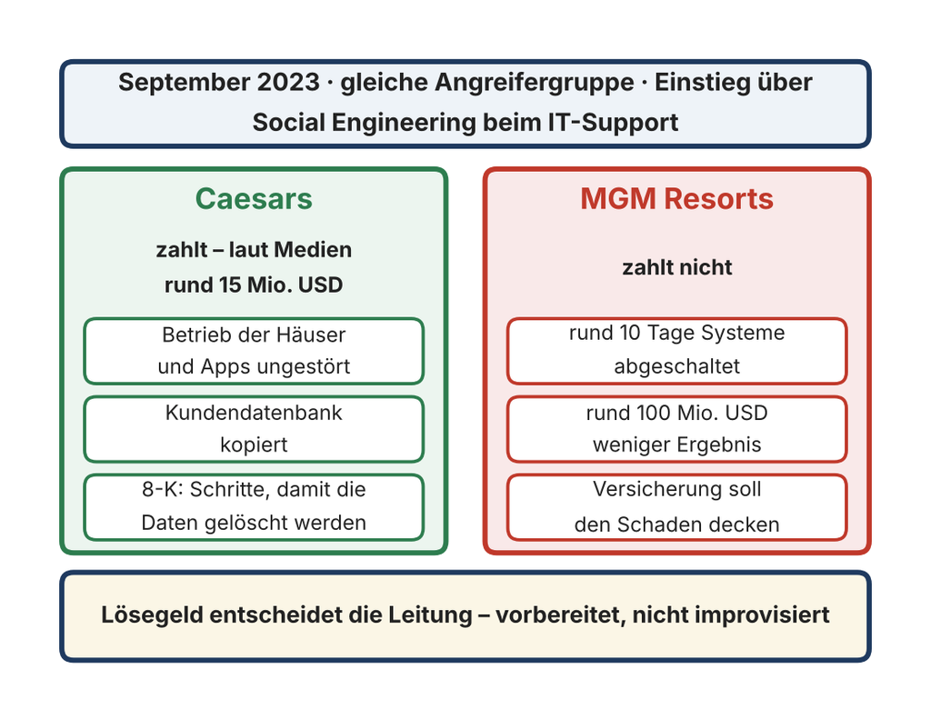

## Kooperation und Grenzen der Rollen

Typische Konfliktlinien und Lösungsprinzipien:

| Konflikt | Ursache | Resiliente Lösung |
| --- | --- | --- |
| CISO vs. CIO | Security vs. Verfügbarkeit | klare Zieltrennung, gemeinsame KPIs |
| SOC vs. IT Ops | „Wer darf eingreifen?“ | Runbooks & Eskalationskriterien |
| CERT vs. PR | Kommunikationsfreigabe | vorab definierte Kommunikationsmatrix |
| BCM vs. Security | Prioritätenunterschiede | Business-Impact-Analysen abstimmen |
| DPO vs. Incident Team | Datenschutzmeldungen | Abstimmung mit Legal-Team & CISO |

## Governance-Matrix (Beispiel)

Verantwortung ersetzt Diskussion.

| Entscheidungsfeld | Primär | Stellvertretend | Information |
| --- | --- | --- | --- |
| Isolierung eines Systems | CERT | IT Ops | CISO |
| Externe Kommunikation | Management | PR | CISO, DPO |
| Behördenmeldung | DPO / CISO | CISO / DPO | Management |
| Lösegeldfrage | Management | – | CISO, Legal |
| Wiederanlaufentscheidung | BCM | CERT | Management |
| Lessons Learned | CISO | CERT | alle Bereiche |

## Best Practices & Standards

Rahmenwerke und Leitlinien für Rollenmodelle in der Cyber-Organisation:

| Standard / Leitlinie | Relevanz |
| --- | --- |
| ISO/IEC 27001 | Rollen und Verantwortlichkeiten im ISMS |
| ISO/IEC 27035 | Incident-Management-Prozess und Eskalationspfade |
| ISO 22320 | Krisenmanagement und Führungsstrukturen in Notlagen |
| ISO 22316 | Grundprinzipien organisationaler Resilienz |
| BSI-Standard 200-4 | Business Continuity Management |
| NIS-2-Richtlinie (EU) 2022/2555 | Verantwortung der Leitung, Meldepflichten |
| BSIG (Fassung NIS2UmsuCG) | § 32 Meldepflichten, § 38 Pflichten der Geschäftsleitung |

## Übung: Wer macht was im Incident?

**Szenario:** Phishing führt zu kompromittierten Admin-Zugangsdaten; das SOC sieht verdächtige Logins. Gruppen zu 4–5 Personen, 20 Minuten.

1. Wer wird zuerst informiert?
2. Wer entscheidet über die Systemtrennung?
3. Wer kommuniziert intern / extern?
4. Wer bewertet rechtliche Meldepflichten – und wer zählt die Stunden?
5. Wer dokumentiert und berichtet an das Management?

**Ziel:** Rollen abgrenzen → Kollisionspunkte erkennen → gemeinsame Eskalationslogik entwickeln.

## Was die Fälle zeigen

| Fall | Rolle | Lehre |
| --- | --- | --- |
| Target 2013 | SOC → Entscheidung | Ein Alarm braucht einen Eigentümer und eine Eskalationsschwelle |
| Uber 2016 | CISO | Meldeentscheidungen gehören nicht in eine Hand |
| SolarWinds 2023–2025 | CISO | Eskalation dokumentieren, außen sagen, was innen gilt |
| Uniklinik Düsseldorf 2020 | CERT, externe Partner | BSI, Polizei, Leitstelle – vorher bekannt |
| HS Kaiserslautern 2023 | Rollenaufbau | Aus dem Vorfall wird eine Rolle (ISB beim Präsidium) |
| MGM / Caesars 2023 | Management Board | Lösegeld ist Leitungsentscheidung – vorbereitet |

## Kernpunkte

- Rollen sind das **organisatorische Immunsystem** – Erkennen allein reicht nicht (Target).
- Der CISO braucht ein **Mandat und einen Berichtsweg**; Vertuschen endet persönlich (Uber, SolarWinds).
- **SOC erkennt, CERT reagiert** – mit externen Partnern, die vorher bekannt sind (Uniklinik Düsseldorf).
- Rollen entstehen oft erst nach dem Vorfall – **besser vorher** (Hochschule Kaiserslautern).
- Meldepflichten laufen ab Kenntnis; **Leitungsentscheidungen** gehören vorbereitet (MGM, Caesars).

## Ausblick & Hausaufgabe

**Nächste Sitzung:** Technische Resilienz I – Backup, Disaster Recovery, Notfalltests

**Hausaufgabe:** Ergänzen Sie Ihre Rollenkarte aus Sitzung 5 um zwei Zeilen: **Wer darf einen Restore aus dem Backup freigeben** – und **wann wurde zuletzt ein Restore getestet**? Finden Sie für Ihre Organisation heraus, ob es darauf eine Antwort gibt.

Kapitel zum Termin · Skript · Glossar · Quellen